# final project

Aoi, Christina, Ahlam

12/2/2018

### Introduction :

##### Everyone has a billionaire dream. Having money means living in mansions, flying private planes, attending parties and meeting celebrities. It is very unlikely to know a billionaire personally, but we can learn about their life stories from books and interviews. They might not be true, but they gives us some characters to look up to in case someday we might also become billionaires. We assume that billionaires share similar characteristics, which are not possessed by the general public and are essential to the outcome of becoming billionaires. Therefore, we want to investigate the shared characteristics of billionaires.

### Data:

##### The data we found is called “The Billionaire Characteristics Database” from the website OpenDataSoft. It examines the billionaires listed on Forbes for 20 years and collect information about them and their companies according to the magazine Rich People Poor Countries.

##### The observations in the dataset are each billionaire and the columns contain information about themselves and their companies, including age, gender, the industry their business mainly dwell in and many more. To explore the relationship between billionaires and the common characteristics, we use their net worth Net.Worth.Billion as the response variable and the others as predictors. One predictor is Rank, which is the rank of the billionaires in Forbes. As they are ranked based on their net worth, Rank is clearly strongly related to Net.Worth.Billion, but it is not a very informative predictor to interpret the common characteristics of the billionaires.

##### The cleansing process of the data includes excluding rows with N.A and 0 values, creating additional binary predictors based on existing ones and fitting models according to the new variables.

##### Before attempting to find answers to our research question, we first analyzed several of the variables in relationship to the net worth of a billionaire. The following graphs will discuss some of the basic relationships found.

1. Net Worth Billion vs Age (across gender and source of fortune)

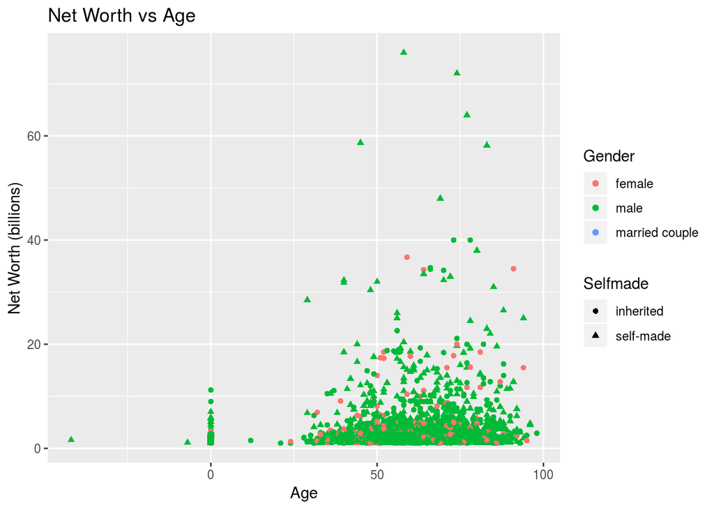

```r
# color code by gender and shape by Selfmade or not
ggplot(gender_n_Selfmade, aes(x = Age, y = Net.Worth.Billion, color = Gender, shape = Selfmade)) +
  geom_point() +
  labs(title = "Net Worth vs Age", y = "Net Worth (billions)")
```

##### The first scatterplot that was constructed summarized the relationship between net worth of a billionaire and age, taking into consideration the gender of the billionaire and whether their fortune was inherited or not. The scatterplot above indicates that the majority of the billionaires are male and so are the ones with the highest net worth. Surprisingly, the majority of the wealthiest female billionaires inherited their fortune while the majority of the wealthiest male billionaires are self made. Furthermore, the majority of the billionaires are aged 50 and above.

2. Net Worth Billion vs Founding Date of the Company (across industries)

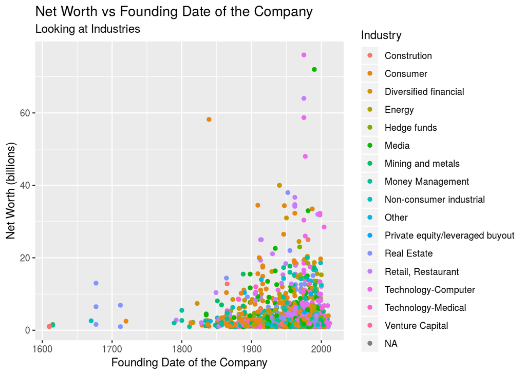

```r
# color code by Industry
ggplot(gender_n_Selfmade2, aes(x = Founding.Date, y = Net.Worth.Billion, color = Industry)) +
  geom_point() +
  labs(title = "Net Worth vs Founding Date of the Company", subtitle = "Looking at Industries", x = "Founding Date of the Company", y = "Net Worth (billions)")
```

##### The second scatterplot describes the relationship between the net worth of a billionaire and the founding date of the company depending on what industry it was part of. In the early 1700s, most of the billionaires that existed were associated with a company that was related to the real estate sector. This is understandable since at that time people were mostly making business out of land and property. As we approach the mid 1900s and early 2000s, more billionaires appear to be associated with companies that are within different sectors such as retail and technology sector. This is also understandable as the economy’s continue to grow and include a wide range of business activities. Finally, the scatterplot indicates that as of the 2000s, the billionaires with the highest net worth are associated with the technology sector.

3. Net Worth Billion vs Founding Date of the Company (across regions)

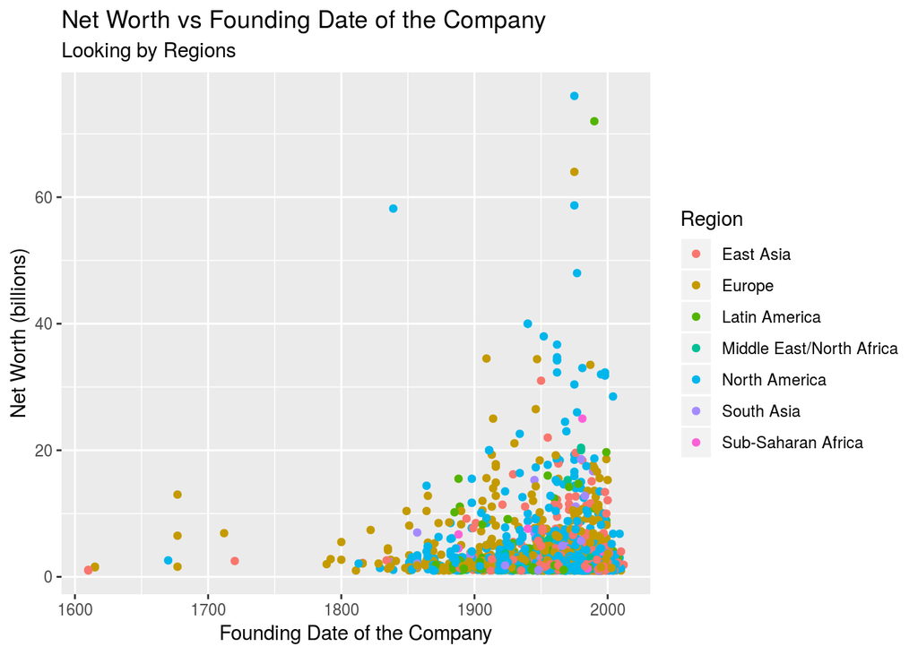

```r
# color code by region
ggplot(gender_n_Selfmade_n_region, aes(x = Founding.Date, y = Net.Worth.Billion, color = Region)) +
  geom_point() +
  labs(title = "Net Worth vs Founding Date of the Company", subtitle = "Looking by Regions", x = "Founding Date of the Company", y = "Net Worth (billions)")
```

##### The third scatter plot describes the relationship among networth of a billionaire and the founding date of their company depending on the region they come from. For instance, in the early 1700s, there were only few billionaires (with relatively low net worths) and the majority of them were of the region Europe. As we approach the mid 1900s and early 2000, more billionaires (with also higher net worth) appear from several different regions. However, the majority of the billionaires, whether they have high net worth or low net worth, are associated with the region Europe or North America.

4. Net Worth Billion vs Age (across each region)

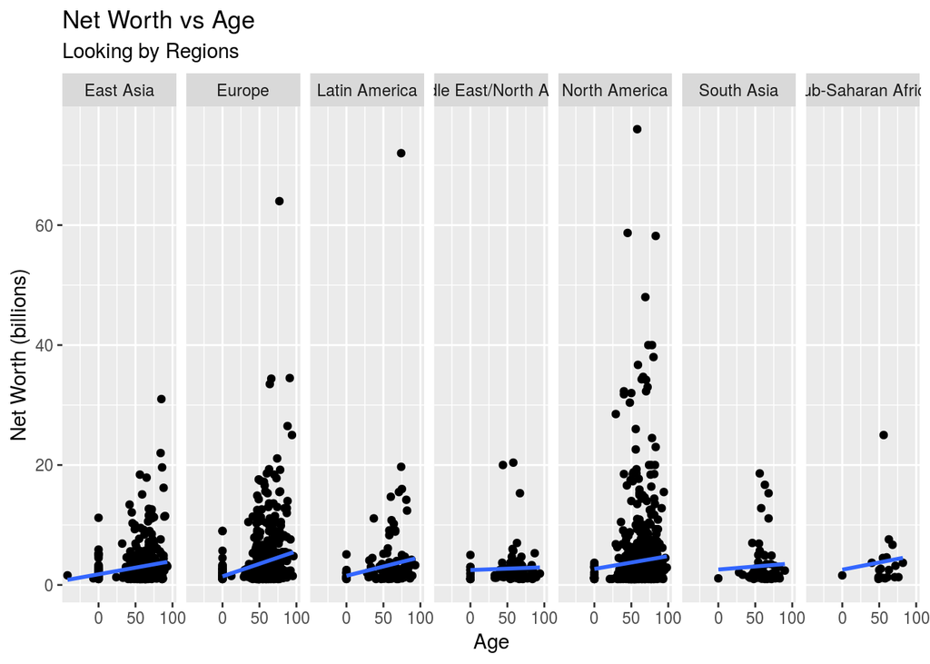

```r
#billionare age dividing by region
ggplot(final_data_1, aes(x = Age, y = Net_Worth_Billion)) +
  geom_point() + facet_grid(. ~Region) + geom_smooth(method = 'lm', se = FALSE) +
  labs(title = "Net Worth vs Age", subtitle = "Looking by Regions", y = "Net Worth (billions)")
```

###### The fourth graph provides scatterplots of net worth of billionaires and age based on each region. Most of the billionaires, despite the region they come from, are aged 50 and above. Also, the scatterplots of North America, Europe and East Asia indicate that numerous billionaires are located in those regions (more dots). According to the data, the wealthiest billionaire is from America, the second wealthiest is from Latin America and the third wealthiest is from Europe. Furthermore, each scatterplot includes a regression line that fits the relationship between Age and the Net Worth (billion) in that specific region. The strongest positive relationship between age and net worth billion (steepest regression line) is found in the scatterplot describing the region Europe. This indicates that out of the 7 regions, it is more common that as a billionaire’s age increases, so does his/her net worth. The weakest relationship between net worth of a billionaire and age is seen in the region Middle East/North Africa. This indicates that net worth of a billionaire doesn’t have a relationship with age of the billionaires.

### Methods:

##### Initially the dataset consisted of 27 independent variables. Throughout the analysis, some independent variables were deleted based on their relevance to our research question. We ended up with 15 variables and as a first step to building a model, we ran a stepwise regression. To simplify the process, we changed the variable age to a categorical variable which summarized age into three groups: young adult, adult and senior. The best model that was generated had errors that were not normally distributed and hence, a transformation was required. However, applying log transformation to our response variable did not lead to normally distributed errors and hence, we could not base our analysis on this model. Thus, our next approach was to use Randomization since it does not require the errors to be normally distributed. From the results, we decided that rank and year should be both excluded. The final model that we constructed focuses on 2014 billionaires based on whether they identify as Westerners or not. Similarily, the errors were not normally distributed, so we applied the randomization procedure.

### Statistics and Results:

#### The model including all variables except age

```r
# construct stepwise selection to get significant variables
stepwise <- regsubsets(Net_Worth_Billion ~ Year + Rank + Industry_Aggregates + Selfmade + Type_of_Wealth + Industry + Relationship_to_Company + Gender + Sector + Company_type + Founding_Date + Political_Connection + Region + Characteristics + age_group + company_age, data = final_data, nbest = 1, really.big = TRUE, method = "seqrep")
```

```
## Reordering variables and trying again:
```

```r
with(summary(stepwise), data.frame(rsq, adjr2, cp, rss, bic, outmat))
```

```
##                rsq     adjr2         cp      rss        bic Year Rank
## 1  ( 1 ) 0.1766834 0.1763337 1247.41106 54073.16  -442.5111         *
## 2  ( 1 ) 0.3401055 0.3395446  534.95518 43340.04  -956.0370    *    *
## 3  ( 1 ) 0.4307828 0.4300567  140.52854 37384.61 -1296.5309    *    *
## 4  ( 1 ) 0.4556751 0.4547490   33.70310 35749.75 -1394.1168    *    *
## 5  ( 1 ) 0.4792120 0.4781039  -67.19639 34203.92 -1490.4948    *    *
## 6  ( 1 ) 0.4948909 0.4936007 -133.74223 33174.17 -1554.7499    *    *
## 7  ( 1 ) 0.5088495 0.5073853 -192.76719 32257.40 -1613.0095    *    *
## 8  ( 1 ) 0.5179473 0.5163042 -230.54115 31659.89 -1649.2950    *    *
## 9  ( 1 ) 0.5241145 0.5222889 -255.50330 31254.84 -1671.8667    *    *
##          Industry_Aggregates0.0 Industry_AggregatesFinancial
## 1  ( 1 )
## 2  ( 1 )
## 3  ( 1 )
## 4  ( 1 )
```

[output cut: 2875 more lines]

##### We chose the model with nine variables because it has the highest adjusted R square, lowest cp and bic variable. The nine variables in the model are Year, Rank, Sector Communication, Sector Fashion, Sector Finance, Sector Software, Sector Technology, Company type acquired and Sector Oil Refining.

```r
m <- lm(Net_Worth_Billion ~ Year + Rank + SectorCommunications + SectorFashion + SectorFinance + SectorSoftware + SectorTechnology + Company_typeacquired + SectorOilRefining, data = final_data_1)
summary(m)
```

```
##
## Call:
## lm(formula = Net_Worth_Billion ~ Year + Rank + SectorCommunications +
##     SectorFashion + SectorFinance + SectorSoftware + SectorTechnology +
##     Company_typeacquired + SectorOilRefining, data = final_data_1)
##
## Residuals:
##     Min      1Q  Median      3Q     Max
## -20.855  -1.813  -0.633   0.633  66.164
##
## Coefficients:
##                        Estimate Std. Error t value Pr(>|t|)
## (Intercept)          -6.879e+02  2.814e+01 -24.446  < 2e-16 ***
## Year                  3.465e-01  1.405e-02  24.665  < 2e-16 ***
## Rank                 -7.501e-03  2.212e-04 -33.905  < 2e-16 ***
## SectorCommunications  2.348e+01  2.391e+00   9.820  < 2e-16 ***
## SectorFashion         3.524e-01  9.068e-01   0.389   0.6976
## SectorFinance         2.142e+00  1.197e+00   1.789   0.0738 .
## SectorSoftware        7.740e-01  5.167e-01   1.498   0.1343
## SectorTechnology      3.734e+00  6.643e-01   5.621 2.12e-08 ***
## Company_typeacquired  1.213e+01  1.568e+00   7.733 1.55e-14 ***
## SectorOilRefining     1.033e+00  4.137e+00   0.250   0.8029
## ---
## Signif. codes:  0 '***' 0.001 '**' 0.01 '*' 0.05 '.' 0.1 ' ' 1
##
## Residual standard error: 4.135 on 2346 degrees of freedom
##   (6 observations deleted due to missingness)
## Multiple R-squared:  0.3894, Adjusted R-squared:  0.387
## F-statistic: 166.2 on 9 and 2346 DF,  p-value: < 2.2e-16
```

#### Before transformation

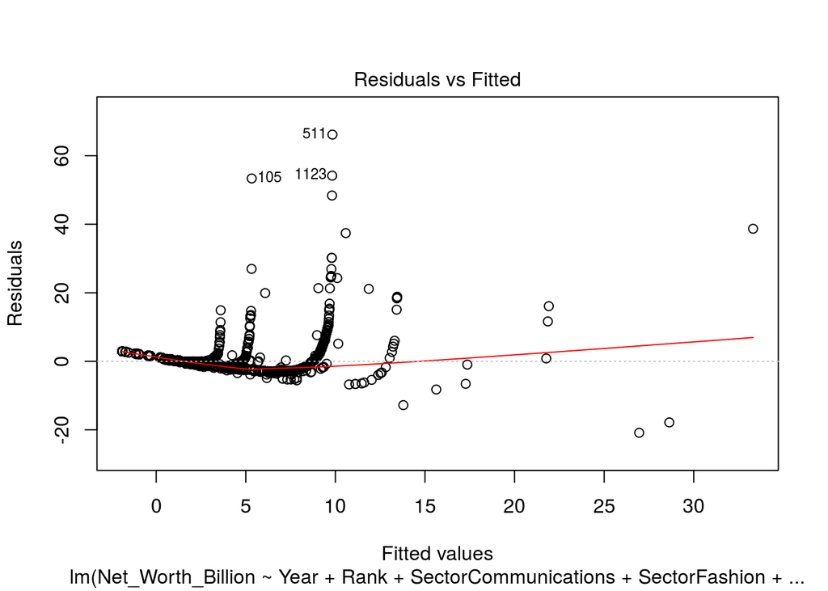

```r
plot(m,  which = 1)
```

##### The plot does not follow a linear trend which violates linearity. Therefore, we applied transformation.

#### transformation

```r
m2 <- lm(log(Net_Worth_Billion) ~ Year + Rank + SectorCommunications + SectorFashion + SectorFinance + SectorSoftware + SectorTechnology + Company_typeacquired, data = final_data_1)
summary(m2)
```

```
##
## Call:
## lm(formula = log(Net_Worth_Billion) ~ Year + Rank + SectorCommunications +
##     SectorFashion + SectorFinance + SectorSoftware + SectorTechnology +
##     Company_typeacquired, data = final_data_1)
##
## Residuals:
##      Min       1Q   Median       3Q      Max
## -1.46541 -0.23580 -0.05113  0.16959  2.73100
##
## Coefficients:
##                        Estimate Std. Error t value Pr(>|t|)
## (Intercept)          -1.429e+02  2.367e+00 -60.389  < 2e-16 ***
## Year                  7.210e-02  1.181e-03  61.029  < 2e-16 ***
## Rank                 -1.667e-03  1.860e-05 -89.601  < 2e-16 ***
## SectorCommunications  1.311e+00  2.011e-01   6.519 8.65e-11 ***
## SectorFashion         2.940e-02  7.627e-02   0.385   0.7000
## SectorFinance         2.026e-01  1.007e-01   2.012   0.0443 *
## SectorSoftware        3.759e-02  4.346e-02   0.865   0.3872
## SectorTechnology      3.438e-01  5.587e-02   6.154 8.88e-10 ***
## Company_typeacquired  9.390e-01  1.319e-01   7.118 1.45e-12 ***
## ---
## Signif. codes:  0 '***' 0.001 '**' 0.01 '*' 0.05 '.' 0.1 ' ' 1
##
## Residual standard error: 0.3478 on 2347 degrees of freedom
##   (6 observations deleted due to missingness)
## Multiple R-squared:  0.7875, Adjusted R-squared:  0.7867
## F-statistic:  1087 on 8 and 2347 DF,  p-value: < 2.2e-16
```

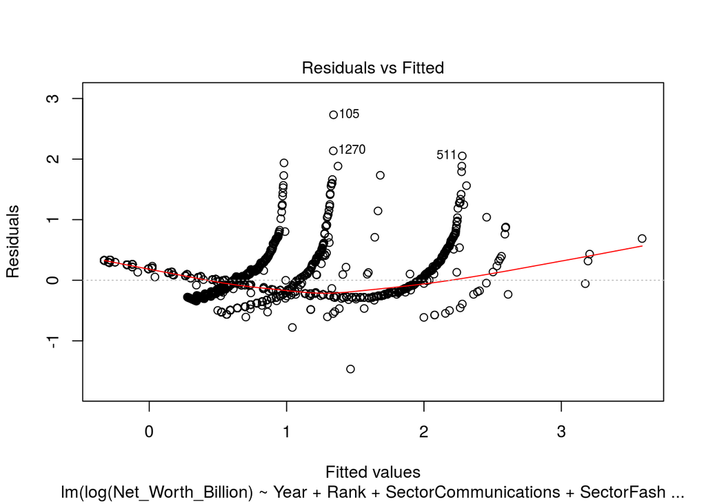

```r
plot(m2,  which = 1)
```

##### Even we applied transformation, the plot still did not follow a linear trend. Therefore, we did a randomization test to see if the model is significant or not.

##### We set the null hypothesis as

$H_0_$ : ρ = 0

$H_a_$ : ρ != 0

```r
# coefficients of the original data
cor(Net_Worth_Billion ~ Year + Rank + SectorCommunications + SectorFashion + SectorFinance + SectorSoftware + SectorTechnology + Company_typeacquired, data = NA_final_data)
```

```
## [1] -0.4150823
```

```r
# point estimate
cor(Net_Worth_Billion ~ shuffle(Year + Rank + SectorCommunications + SectorFashion + SectorFinance + SectorSoftware + SectorTechnology + Company_typeacquired), data = NA_final_data)
```

```
## [1] -0.007940894
```

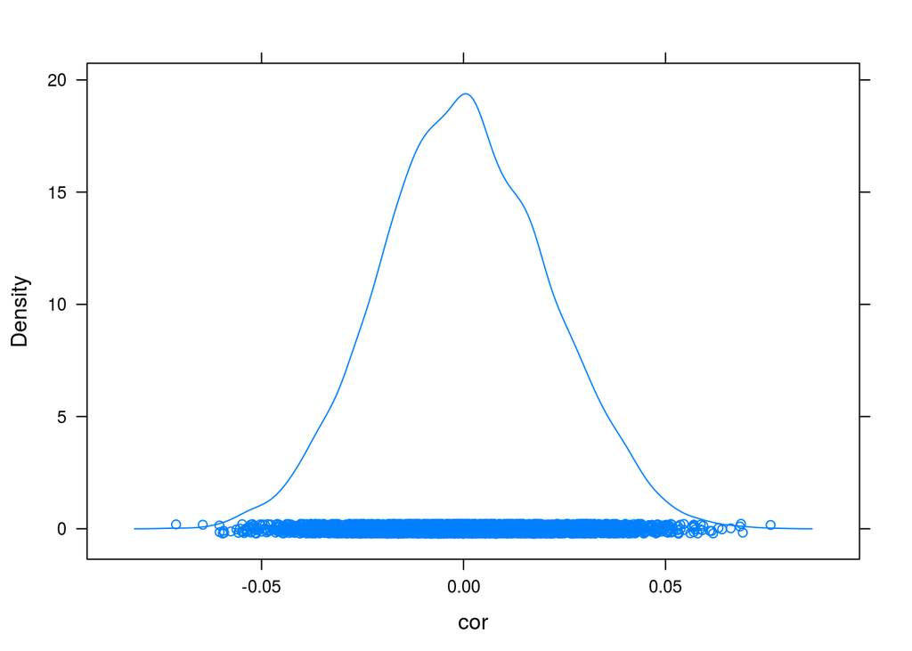

```r
#randomization
rand.test1 <- do(5000) * cor(Net_Worth_Billion ~ shuffle(Year + Rank + SectorCommunications + SectorFashion + SectorFinance + SectorSoftware + SectorTechnology + Company_typeacquired), data = NA_final_data)

densityplot(~cor, data=rand.test1)
```

```r
summary(rand.test1)
```

```
##       cor
##  Min.   :-7.117e-02
##  1st Qu.:-1.389e-02
##  Median : 3.084e-05
##  Mean   : 3.447e-04
##  3rd Qu.: 1.459e-02
##  Max.   : 7.601e-02
```

##### The correlation coefficient of the original data falls in the far left end of the distribution generated by randomization. Therefore, we reject the null hypothesis so the model is significant.

#### Deviding the Billionares into two groups: Western and None Western

```r
# western countries
stepwise_western <- regsubsets(Net_Worth_Billion ~ Industry_Aggregates + Selfmade + Type_of_Wealth + Industry + Relationship_to_Company + Gender + Sector + Company_type + Founding_Date + Political_Connection + Region + Characteristics + age_group + company_age, data = data_western, nbest = 1, really.big = TRUE, method = "seqrep")
```

```
## Reordering variables and trying again:
```

```r
with(summary(stepwise_western), data.frame(rsq, adjr2, cp, rss, bic, outmat))
```

```
##                 rsq       adjr2        cp      rss        bic
## 1  ( 1 ) 0.12383355 0.122948533 -221.6481 36315.33 -117.34216
## 2  ( 1 ) 0.20984835 0.208250467 -294.8822 32750.19 -212.94697
## 3  ( 1 ) 0.26318849 0.260951205 -339.5369 30539.35 -275.38089
## 4  ( 1 ) 0.30039568 0.297560401 -370.0808 28997.19 -319.88382
## 5  ( 1 ) 0.33590266 0.332535023 -399.1375 27525.49 -364.65359
## 6  ( 1 ) 0.37151898 0.367690673 -428.2898 26049.27 -412.43580
## 7  ( 1 ) 0.01528165 0.008276542 -114.7016 40814.59   39.92136
## 8  ( 1 ) 0.41958573 0.414862112 -466.3321 24057.00 -477.56355
## 9  ( 1 ) 0.42988255 0.424657439 -473.3384 23630.22 -488.42035
##          Industry_Aggregates0.0 Industry_AggregatesFinancial
## 1  ( 1 )
## 2  ( 1 )
## 3  ( 1 )
## 4  ( 1 )
```

[output cut: 2875 more lines]

```r
# none western countries
stepwise_none_western <- regsubsets(Net_Worth_Billion ~ Industry_Aggregates + Selfmade + Type_of_Wealth + Industry + Relationship_to_Company + Gender + Sector + Company_type + Founding_Date + Political_Connection + Region + Characteristics + age_group + company_age, data = data_none_western, nbest = 1, really.big = TRUE, method = "seqrep")
```

```
## Reordering variables and trying again:
```

```r
with(summary(stepwise_none_western), data.frame(rsq, adjr2, cp, rss, bic, outmat))
```

```
##                rsq     adjr2        cp      rss       bic
## 1  ( 1 ) 0.3928619 0.3918169 -725.1205 7328.802 -278.1801
## 2  ( 1 ) 0.4433996 0.4414803 -710.9575 6718.759 -322.4797
## 3  ( 1 ) 0.4835536 0.4808777 -699.2936 6234.057 -359.7642
## 4  ( 1 ) 0.5087796 0.5053802 -691.2224 5929.553 -382.5918
## 5  ( 1 ) 0.5337549 0.5297147 -683.2116 5628.074 -406.6454
## 6  ( 1 ) 0.5537375 0.5490889 -676.4024 5386.863 -425.8150
## 7  ( 1 ) 0.5725207 0.5673166 -669.8818 5160.130 -444.5167
## 8  ( 1 ) 0.5854271 0.5796491 -664.7756 5004.336 -456.0216
## 9  ( 1 ) 0.5968292 0.5904967 -660.0315 4866.700 -465.9124
##          Industry_Aggregates0.0 Industry_AggregatesFinancial
## 1  ( 1 )
## 2  ( 1 )
## 3  ( 1 )
## 4  ( 1 )
```

[output cut: 2875 more lines]

#### Multiple Regression model for Western

```r
mod_western <- lm(Net_Worth_Billion ~ Chocolate + Vice_chairman + Fashion + Finance + Investment_via + Oil_refining + Software + Technology + Acquired, data_western )

summary(mod_western)
```

```
##
## Call:
## lm(formula = Net_Worth_Billion ~ Chocolate + Vice_chairman +
##     Fashion + Finance + Investment_via + Oil_refining + Software +
##     Technology + Acquired, data = data_western)
##
## Residuals:
##     Min      1Q  Median      3Q     Max
## -11.350  -2.597  -1.747   0.013  71.953
##
## Coefficients:
##                Estimate Std. Error t value Pr(>|t|)
## (Intercept)      4.0472     0.2015  20.090  < 2e-16 ***
## Chocolate       22.4528     6.1171   3.671 0.000255 ***
## Vice_chairman    0.5028     4.3278   0.116 0.907529
## Fashion          0.8995     1.5914   0.565 0.572046
## Finance          5.2278     3.0635   1.706 0.088234 .
## Investment_via  20.4528     6.1171   3.344 0.000858 ***
## Oil_refining    -2.6972     6.1171  -0.441 0.659363
## Software         0.7163     1.2158   0.589 0.555902
## Technology       9.3028     1.4550   6.394 2.50e-10 ***
## Acquired        27.3195     3.5355   7.727 2.71e-14 ***
## ---
## Signif. codes:  0 '***' 0.001 '**' 0.01 '*' 0.05 '.' 0.1 ' ' 1
##
## Residual standard error: 6.114 on 982 degrees of freedom
##   (2 observations deleted due to missingness)
## Multiple R-squared:  0.1144, Adjusted R-squared:  0.1063
## F-statistic:  14.1 on 9 and 982 DF,  p-value: < 2.2e-16
```

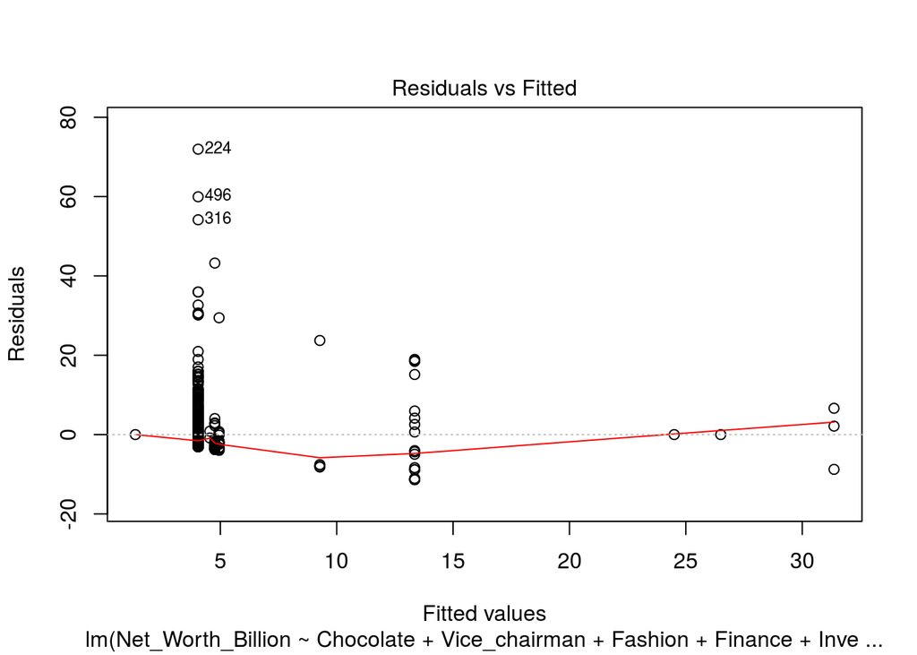

```r
plot(mod_western, which = 1)
```

##### The distribution is not normal so we applied randomization.

```r
# coefficients of the original data
cor(Net_Worth_Billion ~ Chocolate + Vice_chairman + Fashion + Finance + Investment_via + Oil_refining + Software + Technology + Acquired, data = na_data_western)
```

```
## [1] 0.1930234
```

```r
# point estimate
cor(Net_Worth_Billion ~ shuffle(Chocolate + Vice_chairman + Fashion + Finance + Investment_via + Oil_refining + Software + Technology + Acquired), data = na_data_western)
```

```
## [1] -0.012097
```

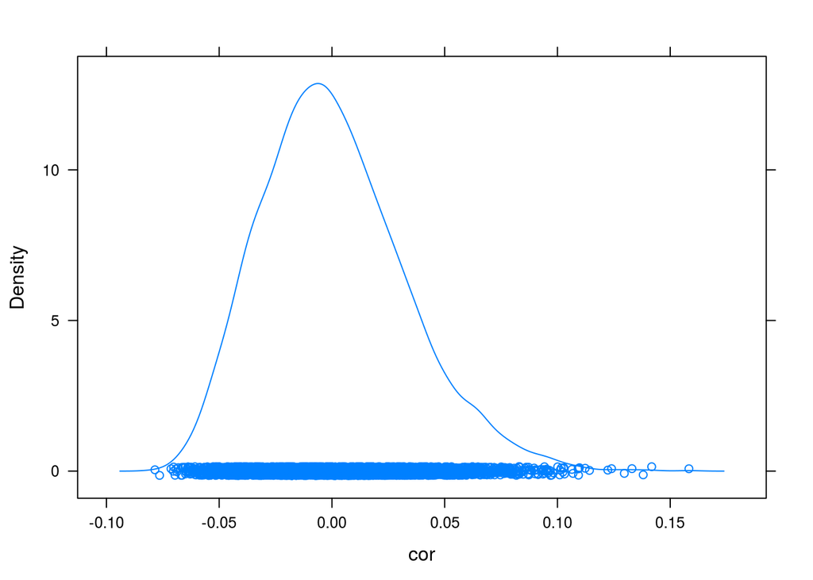

```r
#randomization
rand.test_western <- do(5000) * cor(Net_Worth_Billion ~ shuffle(Chocolate + Vice_chairman + Fashion + Finance + Investment_via + Oil_refining + Software + Technology + Acquired), data = na_data_western)

densityplot(~cor, data=rand.test_western)
```

```r
summary(rand.test_western)
```

```
##       cor
##  Min.   :-0.0784942
##  1st Qu.:-0.0219885
##  Median :-0.0020845
##  Mean   : 0.0007867
##  3rd Qu.: 0.0203302
##  Max.   : 0.1582972
```

##### The coefficient of the original data falls far end of the distribution of randomization, so we reject the null hypothesis and conclude that the model is significant.

#### Multiple Regression model for None Western

```r
mod_none_western <- lm(Net_Worth_Billion ~ CEO + Chairman + Apparel + Commodities + Communications + Construction_real_estate + Construction_real_estate_banking + Internet + Investment_banking_beer, data_none_western )

summary(mod_none_western)
```

```
##
## Call:
## lm(formula = Net_Worth_Billion ~ CEO + Chairman + Apparel + Commodities +
##     Communications + Construction_real_estate + Construction_real_estate_banking +
##     Internet + Investment_banking_beer, data = data_none_western)
##
## Residuals:
##     Min      1Q  Median      3Q     Max
## -5.3143 -1.6444 -0.9944  0.1556 28.0556
##
## Coefficients:
##                                  Estimate Std. Error t value Pr(>|t|)
## (Intercept)                        2.9444     0.1384  21.279  < 2e-16 ***
## CEO                               -1.4444     2.2333  -0.647 0.518052
## Chairman                          -0.9944     0.4802  -2.071 0.038817 *
## Apparel                           14.9556     3.1553   4.740 2.70e-06 ***
## Commodities                       22.0556     3.1553   6.990 7.68e-12 ***
## Communications                    69.0556     3.1553  21.885  < 2e-16 ***
## Construction_real_estate          12.3556     3.1553   3.916 0.000101 ***
## Construction_real_estate_banking  17.4556     3.1553   5.532 4.82e-08 ***
## Internet                           4.2699     1.1995   3.560 0.000402 ***
## Investment_banking_beer            9.9889     1.8252   5.473 6.64e-08 ***
## ---
## Signif. codes:  0 '***' 0.001 '**' 0.01 '*' 0.05 '.' 0.1 ' ' 1
##
## Residual standard error: 3.152 on 573 degrees of freedom
## Multiple R-squared:  0.5283, Adjusted R-squared:  0.5209
## F-statistic: 71.31 on 9 and 573 DF,  p-value: < 2.2e-16
```

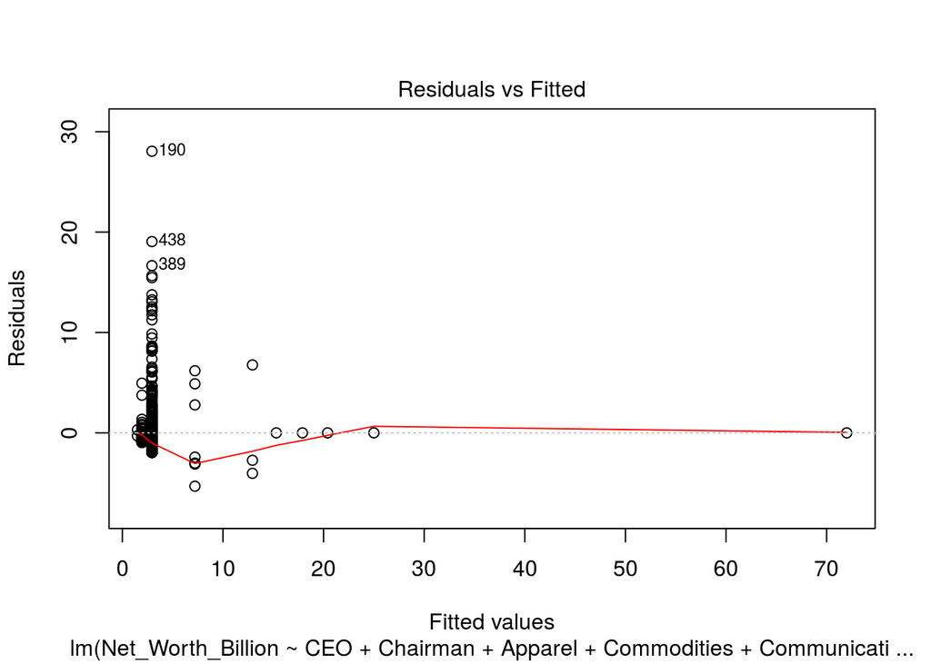

```r
plot(mod_none_western ,  which = 1)
```

##### The distribution is not normal so we applied randomization.

```r
# coefficients of the original data
cor(Net_Worth_Billion ~ CEO + Chairman + Apparel + Commodities + Communications + Construction_real_estate + Construction_real_estate_banking + Internet + Investment_banking_beer, data =  na_none_western)
```

```
## [1] 0.1568423
```

```r
# point estimate
cor(Net_Worth_Billion ~ shuffle(CEO + Chairman + Apparel + Commodities + Communications + Construction_real_estate + Construction_real_estate_banking + Internet + Investment_banking_beer), data = na_none_western)
```

```
## [1] 0.01021276
```

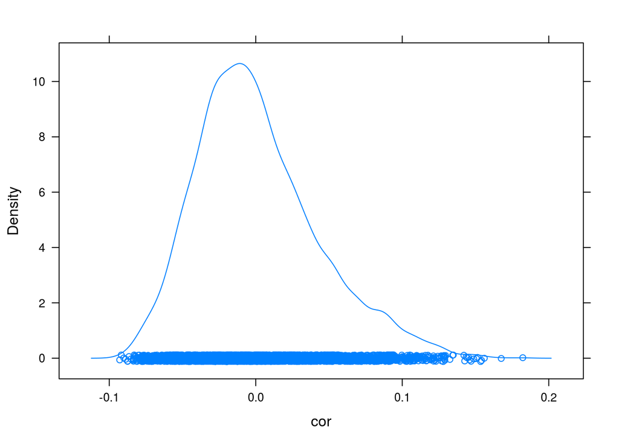

```r
#randomization
rand.test_none <- do(5000) * cor(Net_Worth_Billion ~shuffle(CEO + Chairman + Apparel + Commodities + Communications + Construction_real_estate + Construction_real_estate_banking + Internet + Investment_banking_beer), data = na_none_western)

densityplot(~cor, data=rand.test_none)
```

```r
summary(rand.test_none)
```

```
##       cor
##  Min.   :-0.0928861
##  1st Qu.:-0.0283137
##  Median :-0.0049205
##  Mean   : 0.0009948
##  3rd Qu.: 0.0245019
##  Max.   : 0.1822854
```

### Conclusion

##### The following result did confirm most of our beliefs. We hypothesized that since there are more young CEOs, then there would be more young billionaires. However, the majority of billionares are aged 50 and above.

##### Some of the problems that we encountered in our analysis is the failure of transformation. We were not able to transform the variables in order to get a normally distrition of the errors, and thus, we were limited to using randomization for both models.

##### There were some limitations of the study given that the dataset consisted of several N/A data and unrealistic data such as negative values for age. Therefore, we would have preffered to base our analysis on a complete set of data to be more confident on the results. For instance, we would have preferred to have a gender variable that does not have N/A values and latest data such as of year 2017.

##### The results left us with several questions that we would want to answer. For instance, was there a tremendous change from 2014 to 2017 billionaires? Also, did the relationship between western billionaires and oil refining grow from 2014 given that the U.S. officially became the largest global crude oil producer?

“The Billionaire Characteristics Database.” OpenDataSoft -, data.opendatasoft.com/explore/dataset/the-billionaire-characteristics-database@public-us/table/. #####

“Git hub”-, https://github.com/ChristinaLyu/MTH291_Final_Project.git #####